# Lab 3

Author

Alex Goodman

Download starter .qmd file

**Add your preferred YAML**

The downloaded file **does not** contain an YAML, you need to include your own. This allows you to specify how you would like your rendered HTML to look! The sky is the limit!

Download `hiphop.csv`

**Warning**

Save **both** your .qmd file and your data set in the same folder within your Stat 331 directory! **DO NOT** open your .qmd file straight from your downloads folder.

## Tips for Formatting your Lab

**Tip**

- The first chunk of your Quarto document should be to *declare your libraries* (probably only `tidyverse` for now).
- The second chunk of your Quarto document should be to *load in your data* (using the `here()` function!).
- Make sure you address **all the questions** in these instructions.
- If a question requires **any** type of calculation, **you should provide code for your answer!**
- I have provided hints about functions that might be useful to you. You are **not required** to use these functions.
- You may have to Google to solve some of these!
- Be sure to **save** your work regularly (`Ctrl/Cmd + S` or `File > Save` or the floppy disk icon)
- Be sure to **render** your file every so often, to check for errors and make sure it looks nice.
  - Make your Quarto document does not contain `View(dataset)` or `install.packages("package")`, both of these will prevent rendering.
  - Check your Quarto document for moments when you looked at the data by typing the name of the data frame. Leaving these in means the whole dataset will print out and this looks unprofessional.
  - If you are unable to finish due to errors in your code, remember that you can still submit an HTML file if you specify `error: true` in your `execute` options (in the YAML).

# Data Set

The data set `hiphop` contains results from a study conducted by a linguist at the University of Minnesota. The researcher was interested in predicting musical taste based on familiarity with African American English (AAE). 168 subjects participated in the study, and each was asked to define 64 different AAE terms. The definitions given were used to create a `familiarity` score for each subject for each term. This score quantifies how well the subject knew the term on a scale of 1-5 (1 = not at all, 5 = very well). Before tackling the problems, study the description of each variable [here](http://conservancy.umn.edu/bitstream/handle/11299/116327/5/explanationAAEHiphopChesley.txt).

**1. Load the appropriate R packages and import the data set, `hiphop`.**

```r
# code chunk for loading packages and importing the data
library(tidyverse)
library(here)
hiphop <- read_csv(here("Week 3", "Lab 3", "hiphop.csv"))
```

## Summary

**2. Provide a brief overview (2-4 sentences) of the data set.**

```r
# you may want to use code to answer this question
```

```r
# you may want to use code to answer this question
dim(hiphop)
```

```
[1] 10752    38
```

```r
str(hiphop)
```

```
spc_tbl_ [10,752 × 38] (S3: spec_tbl_df/tbl_df/tbl/data.frame)
 $ word               : chr [1:10752] "[to be] ghost" "[to be] ghost" "[to be] ghost" "[to be] ghost" ...
 $ subj               : chr [1:10752] "p15" "p53" "p136" "p36" ...
 $ sex                : chr [1:10752] "Female" "Female" "Male" "Female" ...
 $ age                : num [1:10752] 20 17 41 18 18 19 18 18 19 19 ...
 $ ethnic             : chr [1:10752] "white" "white" "white" "white" ...
 $ city               : num [1:10752] 33283 34033 8789 712 24280 ...
 $ county             : num [1:10752] 1156212 396500 58696 148955 153504 ...
 $ intl               : num [1:10752] 0 0 0 0 0 0 0 0 0 0 ...
 $ vocal              : num [1:10752] 0 0 2 0 3 0 0 0 0 1 ...
 $ classical          : num [1:10752] 0 0 0 0 3 0 0 0 0 0 ...
 $ folk               : num [1:10752] 0 0 0 1 0 0 2 0 0 0 ...
 $ rock               : num [1:10752] 1 0 0 1 1 0 0 1 0 4 ...
 $ country            : num [1:10752] 3 1 0 2 0 1 0 3 0 4 ...
 $ pop                : num [1:10752] 4 3 0 2 3 1 0 1 0 4 ...
 $ alternative        : num [1:10752] 1 0 0 3 1 0 3 1 0 4 ...
 $ hiphop             : num [1:10752] 7 3 0 3 0 3 0 4 5 0 ...
 $ unclassifiable     : num [1:10752] 0 0 0 0 0 0 0 0 0 0 ...
 $ countyBlack        : num [1:10752] 126221 18064 413 24 6115 ...
 $ jayz               : num [1:10752] 5 5 1 5 1 5 5 5 5 1 ...
 $ barkley            : num [1:10752] 5 1 1 3 1 5 1 2 5 1 ...
 $ boondocks          : num [1:10752] 1 1 1 1 1 1 1 5 5 1 ...
 $ monique            : num [1:10752] 4 3 1 1 1 1 3 1 3 1 ...
 $ bieber             : num [1:10752] 6 6 1 4 2 3 2.5 1 2 2 ...
 $ asianMove          : num [1:10752] 3 0 0 1 0.75 0 0 0 5 1 ...
 $ blackMove          : num [1:10752] 3 0 0 0 0.592 ...
 $ hispanicMove       : num [1:10752] 2 1 0 0 0.353 ...
 $ nativeMove         : num [1:10752] 0 0 0 0 0.0318 ...
 $ SAAMEMove          : num [1:10752] 0 0 0 0 0.295 ...
 $ whiteMove          : num [1:10752] 9 1 2 9 6.29 ...
 $ blackWeekly        : num [1:10752] 3 0 0 1 5 3 2 7 6 1 ...
 $ jayz1              : num [1:10752] 1 1 0 1 0 1 1 1 1 0 ...
 $ boondocks1         : num [1:10752] 0 0 0 0 0 0 0 1 1 0 ...
 $ familiarity        : num [1:10752] 1 1 1 1 1 1 1 1 5 1 ...
 $ trial              : num [1:10752] 26 14 3 12 53 23 25 16 2 29 ...
 $ fam1               : num [1:10752] 0 0 0 0 0 0 0 0 1 0 ...
 $ popularityScore    : num [1:10752] 33 33 33 33 33 33 33 33 33 33 ...
 $ numPreferredArtists: num [1:10752] 1 1 NA 0 NA 0 NA 1 0 NA ...
 $ numOverallArtists  : num [1:10752] 7 7 NA 7 NA 7 NA 7 7 NA ...
 - attr(*, "spec")=
```

[output cut: 26 more lines]

```
  ..   hispanicMove = col_double(),
  ..   nativeMove = col_double(),
  ..   SAAMEMove = col_double(),
  ..   whiteMove = col_double(),
  ..   blackWeekly = col_double(),
  ..   jayz1 = col_double(),
  ..   boondocks1 = col_double(),
  ..   familiarity = col_double(),
  ..   trial = col_double(),
  ..   fam1 = col_double(),
  ..   popularityScore = col_double(),
  ..   numPreferredArtists = col_double(),
  ..   numOverallArtists = col_double()
  .. )
 - attr(*, "problems")=<externalptr>
```

## Cleaning the Data

**4. Missing values for some of the variables were replaced with other values. How were missing values replaced? What do you believe are some benefits and drawbacks of doing this?**

```r
# you may want to use code to answer this question
```

Missing values were replaced with mean values of the -Move variables and blackWeekly. Some benefits of this would be that it is easier to fill in these values, since they are more representative of the sample size, and it isn’t an arbitrary value / NA. This means that you can perform counts and other operations on rows and columns with each datapoint being of numeric value. Some drawbacks are that the new datapoints may not be closely accurate to what the actual participants believe, and it might skew the data towards the mean if there are a lot of missing values present.

**5. Clean the data set in whichever ways you see fit. This might mean adjusting *variable type*, for example from `character` to `factor`, or dealing with missing data. Assign your cleaned data set to a new data set named `hiphop_clean` – use this data set going forward.**

**Tip**

Helpful functions: `mutate()`, `as.factor()`

Likert scales (1-5) will be read by R as numeric values and MUST be converted to factors.

It would be most efficient to use `across()` in combination with `mutate()` to complete this task.

```r
# code chunk for Q5
hiphop_clean <- hiphop |>
  mutate(
    across( c(asianMove, blackMove, hispanicMove, nativeMove,
    SAAMEMove, whiteMove, blackWeekly, jayz, jayz1, barkley,
    boondocks, boondocks1, monique, bieber), as.factor)) |>
  drop_na(numPreferredArtists, numOverallArtists) |>
  select(word, subj, sex, age, ethnic, jayz:fam1)
```

# Data Summaries

**6. How many unique AAE words were studied in this data set?**

**Tip**

Helpful functions: `distinct()`, `count()`

```r
# code chunk for Q6
hiphop_clean |>
  distinct(word) |>
  summarise()
```

```
# A tibble: 1 × 0
```

```r
hiphop_clean
```

```
# A tibble: 5,120 × 22
   word    subj  sex     age ethnic jayz  barkley boond…¹ monique bieber asian…²
   <chr>   <chr> <chr> <dbl> <chr>  <fct> <fct>   <fct>   <fct>   <fct>  <fct>
 1 [to be… p15   Fema…    20 white  5     5       1       4       6      3
 2 [to be… p53   Fema…    17 white  5     1       1       3       6      0
 3 [to be… p36   Fema…    18 white  5     3       1       1       4      1
 4 [to be… p106  Male     19 white  5     5       1       1       3      0
 5 [to be… p107  Male     18 white  5     2       5       1       1      0
 6 [to be… p102  Male     19 asian  5     5       5       3       2      5
 7 [to be… p60   Fema…    18 white  1     1       1       1       3      0
 8 [to be… p21   Fema…    18 white  1     3       1       1       4      0
 9 [to be… p6    Male     16 white  1     1       5       3       2      0
10 [to be… p175  Male     19 white  5     3       5       4       2      1
# … with 5,110 more rows, 11 more variables: blackMove <fct>,
#   hispanicMove <fct>, nativeMove <fct>, SAAMEMove <fct>, whiteMove <fct>,
#   blackWeekly <fct>, jayz1 <fct>, boondocks1 <fct>, familiarity <dbl>,
#   trial <dbl>, fam1 <dbl>, and abbreviated variable names ¹boondocks,
#   ²asianMove
```

There are 64 unique AAE words studied in this dataset.

**7. Make a new variable that re-categorizes `ethnic` into only two groups, “white” and “non-white”, to simplify your data.**

**Tip**

Helpful functions: `mutate()`, `if_else()`

```r
# code chunk for Q7
hiphop_clean <- hiphop_clean |>
  mutate(hiphop_clean, ethnic = if_else(
    ethnic == 'white', "white", 'non-white'))
hiphop_clean
```

```
# A tibble: 5,120 × 22
   word    subj  sex     age ethnic jayz  barkley boond…¹ monique bieber asian…²
   <chr>   <chr> <chr> <dbl> <chr>  <fct> <fct>   <fct>   <fct>   <fct>  <fct>
 1 [to be… p15   Fema…    20 white  5     5       1       4       6      3
 2 [to be… p53   Fema…    17 white  5     1       1       3       6      0
 3 [to be… p36   Fema…    18 white  5     3       1       1       4      1
 4 [to be… p106  Male     19 white  5     5       1       1       3      0
 5 [to be… p107  Male     18 white  5     2       5       1       1      0
 6 [to be… p102  Male     19 non-w… 5     5       5       3       2      5
 7 [to be… p60   Fema…    18 white  1     1       1       1       3      0
 8 [to be… p21   Fema…    18 white  1     3       1       1       4      0
 9 [to be… p6    Male     16 white  1     1       5       3       2      0
10 [to be… p175  Male     19 white  5     3       5       4       2      1
# … with 5,110 more rows, 11 more variables: blackMove <fct>,
#   hispanicMove <fct>, nativeMove <fct>, SAAMEMove <fct>, whiteMove <fct>,
#   blackWeekly <fct>, jayz1 <fct>, boondocks1 <fct>, familiarity <dbl>,
#   trial <dbl>, fam1 <dbl>, and abbreviated variable names ¹boondocks,
#   ²asianMove
```

**9. What are the demographics of the people in this study? Investigate the variables `sex`, `age`, and `ethnic` and summarize your findings in 1-3 complete sentences.**

**Tip**

You’ll need to first manipulate your data to have each person represented only once.

Helpful functions: `select()`, `distinct(___, .keep_all = TRUE)`, `count()`, `summary()`

```r
# code chunk for Q9
hiphop_clean |>
  select(subj, sex, age, ethnic) |>
  distinct(subj, .keep_all = TRUE) |>
  summary()
```

```
     subj               sex                 age           ethnic
 Length:80          Length:80          Min.   :16.00   Length:80
 Class :character   Class :character   1st Qu.:18.00   Class :character
 Mode  :character   Mode  :character   Median :18.00   Mode  :character
                                       Mean   :19.55
                                       3rd Qu.:20.00
                                       Max.   :42.00
```

```r
count(hiphop_clean)
```

```
# A tibble: 1 × 1
      n
  <int>
1  5120
```

```r
hiphop_clean
```

```
# A tibble: 5,120 × 22
   word    subj  sex     age ethnic jayz  barkley boond…¹ monique bieber asian…²
   <chr>   <chr> <chr> <dbl> <chr>  <fct> <fct>   <fct>   <fct>   <fct>  <fct>
 1 [to be… p15   Fema…    20 white  5     5       1       4       6      3
 2 [to be… p53   Fema…    17 white  5     1       1       3       6      0
 3 [to be… p36   Fema…    18 white  5     3       1       1       4      1
 4 [to be… p106  Male     19 white  5     5       1       1       3      0
 5 [to be… p107  Male     18 white  5     2       5       1       1      0
 6 [to be… p102  Male     19 non-w… 5     5       5       3       2      5
 7 [to be… p60   Fema…    18 white  1     1       1       1       3      0
 8 [to be… p21   Fema…    18 white  1     3       1       1       4      0
 9 [to be… p6    Male     16 white  1     1       5       3       2      0
10 [to be… p175  Male     19 white  5     3       5       4       2      1
# … with 5,110 more rows, 11 more variables: blackMove <fct>,
#   hispanicMove <fct>, nativeMove <fct>, SAAMEMove <fct>, whiteMove <fct>,
#   blackWeekly <fct>, jayz1 <fct>, boondocks1 <fct>, familiarity <dbl>,
#   trial <dbl>, fam1 <dbl>, and abbreviated variable names ¹boondocks,
#   ²asianMove
```

According to the above analysis, the mean age is around 19 years old, with ages spanning between 16 and 42. There are more females than males (3584 vs. 1536), respectively. There are more white than non-white participants (3968 vs 1152).

**10. Make at least two plots to display the demographic information of the subjects in this study.**

**Note**

You do not need to discuss these plots, but make sure they are appropriate to the data types and have informative titles and axis labels. Feel free to use the skills you learned in Challenge 2 to enhance your plots!

```r
# code chunk for Q10
ggplot(data=hiphop_clean) +
  geom_histogram(mapping = aes(x= ethnic, fill = sex),
  position = position_dodge()) +
  labs(x ="Ethnicity", title = "Subject Ethnicity by Sex")
```

[output not shown]

```
Error in `geom_histogram()`:
! Problem while computing stat.
ℹ Error occurred in the 1st layer.
Caused by error in `setup_params()`:
! `stat_bin()` requires a continuous x aesthetic
✖ the x aesthetic is discrete.
ℹ Perhaps you want `stat="count"`?
```

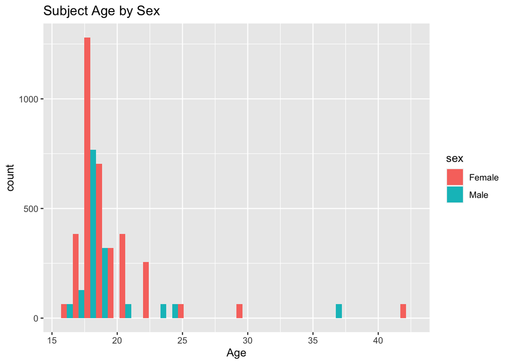

```r
ggplot(data=hiphop_clean) +
  geom_histogram(mapping = aes(x = age, fill = sex),
  position = position_dodge()) +
  labs(x = 'Age', title = 'Subject Age by Sex')
```

## Familiar words

For each demographic group listed below, determine which word(s) in this study was(were) the most **and** least familiar on average.

**Tip**

Helpful functions: `filter()`, `group_by()`, `summarize()`, `slice_max()`, `slice_min()`

Useful variables: `word`, `familiarity`, `sex`, `age`, `ethnic`

**11. People below the age of 20.**

```r
# code chunk for Q11
hiphop_clean |>
  filter(familiarity == 5, age < 20) |>
  arrange(subj, desc(familiarity), by_group = TRUE) |>
  group_by(familiarity) |>
  count(word, sort=TRUE)
```

```
# A tibble: 59 × 3
# Groups:   familiarity [1]
   familiarity word             n
         <dbl> <chr>        <int>
 1           5 feel me         49
 2           5 off the hook    44
 3           5 hella           38
 4           5 what it do      38
 5           5 boo             35
 6           5 finna           33
 7           5 ashy            28
 8           5 5-0             25
 9           5 chedda          25
10           5 make it rain    24
# … with 49 more rows
```

```r
hiphop_clean |>
  filter(familiarity == 1, age < 20) |>
  arrange(familiarity, desc(familiarity), by_group = TRUE) |>
  group_by(familiarity) |>
  count(word, sort=TRUE)
```

```
# A tibble: 64 × 3
# Groups:   familiarity [1]
   familiarity word                  n
         <dbl> <chr>             <int>
 1           1 The Nation           58
 2           1 catch the vapors     57
 3           1 domino               57
 4           1 face gator           56
 5           1 humming              56
 6           1 rollie               56
 7           1 break someone out    55
 8           1 grip grain           55
 9           1 saditty              55
10           1 dollar cab           54
# … with 54 more rows
```

The words that were most familiar with those under 20 were feel me, off the hook, etc. and the words that were least familiar were The Nation, catch the vapors, etc. on average.

**12. Non-white women.**

```r
# code chunk for Q12
hiphop_clean |>
  filter(ethnic == 'non-white', sex == "Female", familiarity == 5) |>
  arrange(familiarity, desc(familiarity), by_group = TRUE) |>
  group_by(familiarity) |>
  count(word, sort=TRUE)
```

```
# A tibble: 49 × 3
# Groups:   familiarity [1]
   familiarity word             n
         <dbl> <chr>        <int>
 1           5 feel me         12
 2           5 what it do      11
 3           5 boo             10
 4           5 finna           10
 5           5 off the hook     9
 6           5 A-town           8
 7           5 ashy             8
 8           5 ballin'          7
 9           5 chedda           7
10           5 hella            7
# … with 39 more rows
```

```r
hiphop_clean |>
  filter(ethnic == 'non-white', sex == "Female", familiarity == 1) |>
  arrange(familiarity, desc(familiarity), by_group = TRUE) |>
  group_by(familiarity) |>
  count(word, sort=TRUE)
```

```
# A tibble: 64 × 3
# Groups:   familiarity [1]
   familiarity word                  n
         <dbl> <chr>             <int>
 1           1 break someone out    14
 2           1 dollar cab           14
 3           1 domino               14
 4           1 dukey rope           14
 5           1 humming              14
 6           1 plex                 14
 7           1 rollie               14
 8           1 The Nation           14
 9           1 catch the vapors     13
10           1 cop my steezy        13
# … with 54 more rows
```

The words that were most familiar among non-white women were feel me, what it do, etc. and the words that were least familiar among non-white women were break someone out, dollar cab, etc.

**13. White men above the age of 30.**

```r
# code chunk for Q13
hiphop_clean |>
  filter(ethnic == 'white', sex == "Male", age > 30,
         familiarity == 5) |>
  arrange(familiarity, desc(familiarity), by_group = TRUE) |>
  group_by(familiarity) |>
  count(word, sort=TRUE)
```

```
# A tibble: 3 × 3
# Groups:   familiarity [1]
  familiarity word             n
        <dbl> <chr>        <int>
1           5 5-0              1
2           5 hard             1
3           5 make it rain     1
```

```r
hiphop_clean |>
  filter(ethnic == 'white', sex == "Male", age > 30,
         familiarity == 1) |>
  arrange(familiarity, desc(familiarity), by_group = TRUE) |>
  group_by(familiarity) |>
  count(word, sort=TRUE)
```

```
# A tibble: 59 × 3
# Groups:   familiarity [1]
   familiarity word                  n
         <dbl> <chr>             <int>
 1           1 [to be] ghost         1
 2           1 A-town                1
 3           1 ashy                  1
 4           1 ay yo trip            1
 5           1 ballin'               1
 6           1 beezy                 1
 7           1 bones                 1
 8           1 boo                   1
 9           1 boughie               1
10           1 break someone out     1
# … with 49 more rows
```

A joke among the [Tidy Tuesday](https://www.tidytuesday.com/) community is that Justin Bieber was one of the subjects in this study. Bieber, a white male, from a relatively small town (10,000-60,000 people) in Ontario would have been 17-23 at the time of the study.

**14. Determine which subject you believe is secretly Bieber, justify your answer.**

**Tip**

Refer again to the data set description. There is another clue about Bieber’s identity.

```r
# code chunk for Q14
hiphop_clean |>
  filter(bieber == 5, ethnic == "white", sex == "Male", age > 17, age < 23)
```

```
# A tibble: 64 × 22
   word    subj  sex     age ethnic jayz  barkley boond…¹ monique bieber asian…²
   <chr>   <chr> <chr> <dbl> <chr>  <fct> <fct>   <fct>   <fct>   <fct>  <fct>
 1 [to be… p17   Male     18 white  5     1       1       4       5      0
 2 5-0     p17   Male     18 white  5     1       1       4       5      0
 3 A-town  p17   Male     18 white  5     1       1       4       5      0
 4 ashy    p17   Male     18 white  5     1       1       4       5      0
 5 ay yo … p17   Male     18 white  5     1       1       4       5      0
 6 ballin' p17   Male     18 white  5     1       1       4       5      0
 7 beezy   p17   Male     18 white  5     1       1       4       5      0
 8 bones   p17   Male     18 white  5     1       1       4       5      0
 9 boo     p17   Male     18 white  5     1       1       4       5      0
10 boughie p17   Male     18 white  5     1       1       4       5      0
# … with 54 more rows, 11 more variables: blackMove <fct>, hispanicMove <fct>,
#   nativeMove <fct>, SAAMEMove <fct>, whiteMove <fct>, blackWeekly <fct>,
#   jayz1 <fct>, boondocks1 <fct>, familiarity <dbl>, trial <dbl>, fam1 <dbl>,
#   and abbreviated variable names ¹boondocks, ²asianMove
```

```r
slice_max(bieber)
```

```
Error in slice_max(bieber): object 'bieber' not found
```

# Lab 3 Submission

You will submit **only** your rendered HTML file. Your HTML file is required to have the following specifications in the YAML options (at the top of your document):

- be self-contained (`self-contained: true`)
- include your source code (`code-tools: true`)
- include all your code and output (`echo: true`)
- include **no** messages from loading in packages or the data (`messages: false`)

**If any of the options are not included, your Lab 3 or Challenge 3 assignment will receive an “Incomplete” and you will be required to submit a revision.**

# Challenge 3: Group Comparisons & Data Ethics

## Published Comparisons

In the published article ([You Know What It Is: Learning Words through Listening to Hip-Hop](https://journals.plos.org/plosone/article/file?id=10.1371/journal.pone.0028248&type=printable)), the author presents a series of comparisons about the variables which most explain an individual’s familiarity with African American English (AAE).

Let us instead compare the number of artists participants reported liking for each genre. Specifically, you will determine which music genre most differentiates each of the demographic groups provided.

> Which genre had much higher average (mean or median) reported artists in one group than the other.
> - Male versus Female
> - White versus Non-White

**Tip**

You might find it helpful to first create a new data set with only the variables you are interested in! Look at the Music Variables in the data set description along with the demographics of interest.

Helpful functions: `select()`, `group_by()`, `summarize()`, `across()`

Other useful operations in R: `mean()`, `diff()`, `abs()`, `which.max()`

## Study Design Critique – Data Ethics

Myself, members of the Tidy Tuesday community, and previous 331 students have voiced concerns regarding the design and social context of this study.

You’ve already read the [data description (link)](http://conservancy.umn.edu/bitstream/handle/11299/116327/5/explanationAAEHiphopChesley.txt) regarding how participants were recruited for participation in this study. **Now**, you need to read additional details regarding aspects of the study in the published paper: [You Know What It Is: Learning Words through Listening to Hip-Hop](https://journals.plos.org/plosone/article/file?id=10.1371/journal.pone.0028248&type=printable).

> Based on the design of this study and its context (African American English), what are **at least two** concerns you have? Keep in mind this critique aligns with conversations regarding data ethics. Thus, your concerns need to address the racial aspects of the design of this study.

# Challenge 3 Submission

Your challenge should be submitted as a **separate file**, **not** at the bottom of your Lab 3 file. Please submit your rendered HTML file. You can copy and paste this code into a **new** Quarto file. Your Challenge 3 submission should only included code necessary for completing the Challenge, nothing else.

You will submit **only** your rendered HTML file. Your HTML file is required to have the following specifications in the YAML options (at the top of your document):

- be self-contained (`self-contained: true`)
- include your source code (`code-tools: true`)
- include all your code and output (`echo: true`)
- include **no** messages from loading in packages or the data (`messages: false`)

**If any of the options are not included, your Lab 3 or Challenge 3 assignment will receive an “Incomplete” and you will be required to submit a revision.**